# High-finance cross-border responses

The twelve presentation scenarios across two regional setups and four closures

## Scope and how to read the page

These are **period-90 responses against each arm’s own unshocked baseline**, computed from stored runs without a new model solve. The presentation set is `sc1`–`sc12`: registry shocks 1–4, 7–13 and 16. The outcome vector holds 37 measures for each of the two regions, covering real activity, fiscal, external, labour/distribution, finance/wealth and ecology. Most responses are percent changes; deficit, current account and trade balance are changes as a percent of own baseline value added; shares and debt/GDP are point changes multiplied by 100. Exact levels, denominators and SHA-256 hashes are recorded in the project’s analysis CSVs named below.

The high-finance **credit** arm now has twelve scenarios under all four closures in both regional setups: 96 response observations. The newly built North/South fiat, quasi-float and OPENFIXG off and credit baselines pass the North/South acceptance gate. North/South fiat shocks use a **declared numerical exception**: a 2.5×10⁻⁵ pre-shock scaled limit instead of 1×10⁻⁵ for other credit arms, while the economic-row absolute limit remains 1×10⁻³. All twelve fiat shocks passed with the same pre-shock scaled maximum, 2.007×10⁻⁵; scenario 1’s economic-row maximum was 7.194×10⁻⁵. The EU/RoW OPENFIXG baseline remains documented-provisional; its responses are measured against that same baseline, and levels should not be compared across closures. The finance-off counterpart has eleven stored presentation scenarios under gold in each setup, so the direct off/credit comparison below uses those 22 matched cells only.

Stored high-finance scenario coverage. Registry 6 is outside the presentation set; North/South gold finance-off lacks registry 16.

| setup | closure | finance | scenarios |
| --- | --- | --- | --- |
| EU/RoW | fiat | credit | 12 |
| North/South | fiat | credit | 12 |
| EU/RoW | gold | credit | 12 |
| North/South | gold | credit | 12 |
| EU/RoW | OPENFIXG | credit | 12 |
| North/South | OPENFIXG | credit | 12 |
| EU/RoW | quasi-float | credit | 12 |
| North/South | quasi-float | credit | 12 |
| EU/RoW | gold | off | 11 |
| North/South | gold | off | 11 |

## Cross-border value-added asymmetries

The sign patterns below use both regions’ real value-added responses. “Contained” means the partner-region response is smaller than 0.003% in absolute value. “Leakage pattern” means the intervening region contracts while its partner expands; the label alone does not prove a sectoral displacement mechanism. “Energy divergence” means intervening-region expansion and partner contraction in an energy scenario. The threshold is inherited from the earlier descriptive classifier, not estimated on this high-finance grid.

Counts of observed period-90 value-added sign patterns.

| setup | closure | regime | scenarios |
| --- | --- | --- | --- |
| EU/RoW | fiat | contained | 4 |
| EU/RoW | fiat | energy divergence | 2 |
| EU/RoW | fiat | leakage pattern | 5 |
| EU/RoW | fiat | other divergence | 1 |
| EU/RoW | gold | contained | 4 |
| EU/RoW | gold | energy divergence | 2 |
| EU/RoW | gold | leakage pattern | 5 |
| EU/RoW | gold | other divergence | 1 |
| EU/RoW | OPENFIXG | contained | 12 |
| EU/RoW | quasi-float | contained | 4 |
| EU/RoW | quasi-float | energy divergence | 2 |
| EU/RoW | quasi-float | leakage pattern | 5 |
| EU/RoW | quasi-float | other divergence | 1 |
| North/South | fiat | contained | 5 |
| North/South | fiat | dual contraction | 1 |
| North/South | fiat | energy divergence | 2 |
| North/South | fiat | leakage pattern | 3 |
| North/South | fiat | other divergence | 1 |
| North/South | gold | contained | 5 |
| North/South | gold | dual contraction | 1 |
| North/South | gold | energy divergence | 2 |
| North/South | gold | leakage pattern | 3 |
| North/South | gold | other divergence | 1 |
| North/South | OPENFIXG | both expand | 1 |
| North/South | OPENFIXG | contained | 4 |
| North/South | OPENFIXG | dual contraction | 3 |
| North/South | OPENFIXG | energy divergence | 2 |
| North/South | OPENFIXG | leakage pattern | 2 |
| North/South | quasi-float | contained | 5 |
| North/South | quasi-float | dual contraction | 1 |
| North/South | quasi-float | energy divergence | 2 |
| North/South | quasi-float | leakage pattern | 3 |
| North/South | quasi-float | other divergence | 1 |

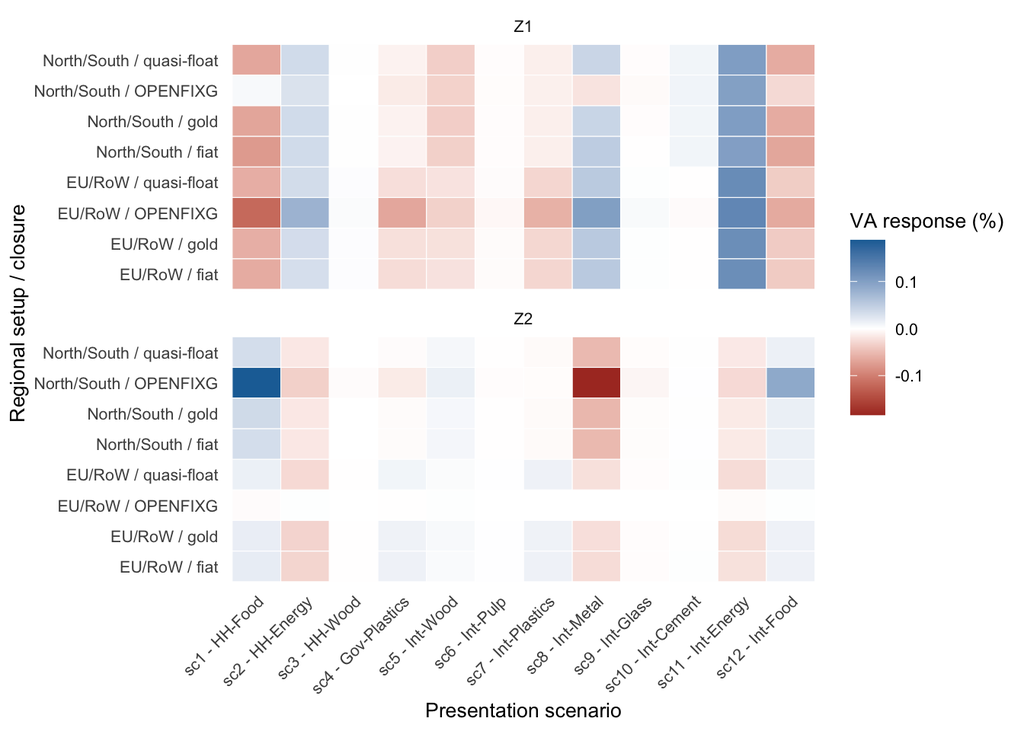

Every high-finance credit observation. Value added is percent deviation from that arm’s own baseline.

| scenario_label | setup | closure | va_Z1 | va_Z2 | regime |
| --- | --- | --- | --- | --- | --- |
| sc1 - HH-Food | EU/RoW | fiat | -0.06324 | 0.01780 | leakage pattern |
| sc1 - HH-Food | EU/RoW | gold | -0.06035 | 0.01666 | leakage pattern |
| sc1 - HH-Food | EU/RoW | OPENFIXG | -0.11977 | -0.00262 | contained |
| sc1 - HH-Food | EU/RoW | quasi-float | -0.06112 | 0.01517 | leakage pattern |
| sc1 - HH-Food | North/South | fiat | -0.07776 | 0.03341 | leakage pattern |
| sc1 - HH-Food | North/South | gold | -0.06800 | 0.03658 | leakage pattern |
| sc1 - HH-Food | North/South | OPENFIXG | 0.00564 | 0.18801 | both expand |
| sc1 - HH-Food | North/South | quasi-float | -0.06669 | 0.03352 | leakage pattern |
| sc2 - HH-Energy | EU/RoW | fiat | 0.03150 | -0.03087 | energy divergence |
| sc2 - HH-Energy | EU/RoW | gold | 0.03393 | -0.03154 | energy divergence |
| sc2 - HH-Energy | EU/RoW | OPENFIXG | 0.07795 | 0.00151 | contained |
| sc2 - HH-Energy | EU/RoW | quasi-float | 0.03496 | -0.02743 | energy divergence |
| sc2 - HH-Energy | North/South | fiat | 0.03526 | -0.01706 | energy divergence |
| sc2 - HH-Energy | North/South | gold | 0.03551 | -0.01684 | energy divergence |
| sc2 - HH-Energy | North/South | OPENFIXG | 0.02821 | -0.03509 | energy divergence |
| sc2 - HH-Energy | North/South | quasi-float | 0.03549 | -0.01685 | energy divergence |
| sc3 - HH-Wood | EU/RoW | fiat | 0.00194 | -0.00097 | contained |
| sc3 - HH-Wood | EU/RoW | gold | 0.00189 | -0.00092 | contained |
| sc3 - HH-Wood | EU/RoW | OPENFIXG | 0.00345 | -0.00027 | contained |
| sc3 - HH-Wood | EU/RoW | quasi-float | 0.00184 | -0.00079 | contained |
| sc3 - HH-Wood | North/South | fiat | 0.00135 | -0.00026 | contained |
| sc3 - HH-Wood | North/South | gold | 0.00123 | -0.00029 | contained |
| sc3 - HH-Wood | North/South | OPENFIXG | 0.00015 | -0.00247 | contained |
| sc3 - HH-Wood | North/South | quasi-float | 0.00121 | -0.00024 | contained |
| sc4 - Gov-Plastics | EU/RoW | fiat | -0.02508 | 0.01301 | leakage pattern |
| sc4 - Gov-Plastics | EU/RoW | gold | -0.02259 | 0.01214 | leakage pattern |
| sc4 - Gov-Plastics | EU/RoW | OPENFIXG | -0.06680 | -0.00067 | contained |
| sc4 - Gov-Plastics | EU/RoW | quasi-float | -0.02343 | 0.01017 | leakage pattern |
| sc4 - Gov-Plastics | North/South | fiat | -0.00870 | -0.00290 | contained |
| sc4 - Gov-Plastics | North/South | gold | -0.00941 | -0.00300 | contained |

[output cut: 66 more lines]

### Ecological response ranges

Material extraction and emissions responses: minimum, median and maximum across the eight credit configurations, percent relative to each arm’s own baseline.

| scenario | zone | measure | minimum | median | maximum |
| --- | --- | --- | --- | --- | --- |
| sc1 - HH-Food | Z1 | emis | -0.58770 | -0.50242 | -0.42619 |
| sc1 - HH-Food | Z1 | x_mat | -0.38420 | -0.34474 | -0.31331 |
| sc1 - HH-Food | Z2 | emis | -0.00812 | 0.03603 | 0.17499 |
| sc1 - HH-Food | Z2 | x_mat | -0.00685 | 0.04613 | 0.17651 |
| sc2 - HH-Energy | Z1 | emis | -1.83487 | -1.32170 | -0.76555 |
| sc2 - HH-Energy | Z1 | x_mat | -0.67209 | -0.49040 | -0.36175 |
| sc2 - HH-Energy | Z2 | emis | -0.05153 | -0.03771 | -0.00362 |
| sc2 - HH-Energy | Z2 | x_mat | -0.06536 | -0.05427 | -0.01523 |
| sc3 - HH-Wood | Z1 | emis | 0.00260 | 0.00395 | 0.00577 |
| sc3 - HH-Wood | Z1 | x_mat | -0.01953 | -0.01504 | -0.01064 |
| sc3 - HH-Wood | Z2 | emis | -0.00087 | 0.00042 | 0.00062 |
| sc3 - HH-Wood | Z2 | x_mat | -0.00195 | -0.00057 | 0.00005 |
| sc4 - Gov-Plastics | Z1 | emis | -0.09095 | -0.03758 | -0.01410 |
| sc4 - Gov-Plastics | Z1 | x_mat | -0.08988 | -0.06467 | -0.06325 |
| sc4 - Gov-Plastics | Z2 | emis | 0.01396 | 0.02252 | 0.03284 |
| sc4 - Gov-Plastics | Z2 | x_mat | -0.03109 | -0.01769 | -0.00368 |
| sc5 - Int-Wood | Z1 | emis | 0.00716 | 0.03362 | 0.04927 |
| sc5 - Int-Wood | Z1 | x_mat | -0.20463 | -0.16694 | -0.11720 |
| sc5 - Int-Wood | Z2 | emis | 0.00360 | 0.01485 | 0.02735 |
| sc5 - Int-Wood | Z2 | x_mat | 0.00317 | 0.01034 | 0.01689 |
| sc6 - Int-Pulp | Z1 | emis | -0.02377 | -0.01408 | -0.00638 |
| sc6 - Int-Pulp | Z1 | x_mat | -0.01929 | -0.01520 | -0.01320 |
| sc6 - Int-Pulp | Z2 | emis | -0.00106 | -0.00004 | 0.00110 |
| sc6 - Int-Pulp | Z2 | x_mat | -0.00127 | -0.00043 | 0.00071 |
| sc7 - Int-Plastics | Z1 | emis | -0.09297 | -0.03541 | -0.00065 |
| sc7 - Int-Plastics | Z1 | x_mat | -0.09859 | -0.07765 | -0.07626 |
| sc7 - Int-Plastics | Z2 | emis | -0.01009 | -0.00558 | 0.00752 |
| sc7 - Int-Plastics | Z2 | x_mat | -0.02751 | -0.01702 | 0.00427 |
| sc8 - Int-Metal | Z1 | emis | 0.29453 | 0.58255 | 0.87423 |
| sc8 - Int-Metal | Z1 | x_mat | -1.50046 | -0.94540 | -0.40894 |
| sc8 - Int-Metal | Z2 | emis | -0.19132 | -0.06352 | -0.00190 |
| sc8 - Int-Metal | Z2 | x_mat | -0.64836 | -0.34476 | -0.09019 |
| sc9 - Int-Glass | Z1 | emis | 0.01106 | 0.06194 | 0.11170 |
| sc9 - Int-Glass | Z1 | x_mat | -0.08094 | -0.06069 | -0.04052 |
| sc9 - Int-Glass | Z2 | emis | -0.00662 | -0.00218 | 0.00046 |
| sc9 - Int-Glass | Z2 | x_mat | -0.01201 | -0.00652 | -0.00199 |
| sc10 - Int-Cement | Z1 | emis | 0.00044 | 0.04423 | 0.08714 |
| sc10 - Int-Cement | Z1 | x_mat | -0.12680 | -0.08888 | -0.05076 |
| sc10 - Int-Cement | Z2 | emis | -0.00426 | -0.00180 | 0.00116 |
| sc10 - Int-Cement | Z2 | x_mat | -0.00356 | -0.00009 | 0.00348 |
| sc11 - Int-Energy | Z1 | emis | -3.63802 | -2.56538 | -1.48011 |
| sc11 - Int-Energy | Z1 | x_mat | -1.22576 | -0.96258 | -0.72313 |
| sc11 - Int-Energy | Z2 | emis | -0.06066 | -0.04506 | -0.01373 |
| sc11 - Int-Energy | Z2 | x_mat | -0.09313 | -0.07701 | -0.03794 |
| sc12 - Int-Food | Z1 | emis | -0.31404 | -0.24100 | -0.17284 |
| sc12 - Int-Food | Z1 | x_mat | -0.20245 | -0.15821 | -0.12810 |
| sc12 - Int-Food | Z2 | emis | 0.00042 | 0.02209 | 0.08705 |
| sc12 - Int-Food | Z2 | x_mat | -0.00035 | 0.02345 | 0.08146 |

These ranges show whether an ecological conclusion survives closure and regional aggregation choices. They do not derive the ranking from demand volumes: extraction and emissions also depend on sector intensities and upstream input requirements.

For example, the Z1 intermediate-metal intervention lowers material extraction in **all eight** configurations (−1.5005% to −0.4089%) while increasing emissions in all eight (+0.2945% to +0.8742%). Intermediate wood also lowers Z1 extraction (−0.2046% to −0.1172%) while raising Z1 emissions (+0.0072% to +0.0493%). The extension-specific signs are a concrete reason not to infer an overall ecological ranking from demand scale alone.

## Balanced three-factor ANOVA

The full analysis decomposes 96 credit responses by scenario, regional setup, closure, and all interactions. For comparison with the earlier interim page, the table also retains the 48-cell EU/RoW closure subgrid and the 24-cell gold setup subgrid. Each retained response column is standardised within its own comparison, then scaled to give each of the six outcome blocks equal total weight. The shares refer to this weighted cross-observation variation. These deterministic factorials are saturated: the shares are sums of squares, with no residual error, F-test or p-value.

| cohort | term | n | features | share_percent |
| --- | --- | --- | --- | --- |
| Full high-finance credit: 12 x 2 x 4 | factor(scenario) | 96 | 74 | 58.84 |
| Full high-finance credit: 12 x 2 x 4 | factor(setup) | 96 | 74 | 1.60 |
| Full high-finance credit: 12 x 2 x 4 | factor(closure) | 96 | 74 | 0.41 |
| Full high-finance credit: 12 x 2 x 4 | factor(scenario):factor(setup) | 96 | 74 | 19.78 |
| Full high-finance credit: 12 x 2 x 4 | factor(scenario):factor(closure) | 96 | 74 | 7.98 |
| Full high-finance credit: 12 x 2 x 4 | factor(setup):factor(closure) | 96 | 74 | 0.37 |
| Full high-finance credit: 12 x 2 x 4 | factor(scenario):factor(setup):factor(closure) | 96 | 74 | 11.03 |
| EU/RoW credit: 12 x 4 | factor(scenario) | 48 | 73 | 79.97 |
| EU/RoW credit: 12 x 4 | factor(closure) | 48 | 73 | 2.14 |
| EU/RoW credit: 12 x 4 | factor(scenario):factor(closure) | 48 | 73 | 17.89 |
| Gold credit: 12 x 2 | factor(scenario) | 24 | 72 | 75.56 |
| Gold credit: 12 x 2 | factor(setup) | 24 | 72 | 2.35 |
| Gold credit: 12 x 2 | factor(scenario):factor(setup) | 24 | 72 | 22.09 |

In the full grid, scenario identity accounts for **58.84%** of standardised, equally block-weighted response variation. Scenario × setup accounts for **19.78%**, scenario × closure for **7.98%**, and the three-way interaction for **11.03%**. Standalone setup and closure shares are only 1.60% and 0.41% respectively: their strongest role here is to change *which scenario* produces which response, and the closure-dependent setup effect differs by scenario. The subgrid shares use different sample-specific standardisations, so they should not be subtracted from the full-grid shares or the older 96-cell ANOVA. The older grid also used different arms and a different twelve-shock set.

## Clustering the available responses

Ward D2 clustering uses Euclidean distances on the same standardised, block-weighted responses. The **pooled** view clusters 96 scenario/configuration observations using both regions’ 74 candidate coordinates. The **scenario-profile** view clusters twelve interventions, keeping each of their eight configurations in separate columns. A silhouette measures separation within the declared feature space; it is not evidence that a cluster is an economic mechanism.

Candidate cuts. The maximum is searched only over k = 2…8.

| cohort | k | silhouette | smallest | singletons |
| --- | --- | --- | --- | --- |
| pooled_96 | 2 | 0.3997 | 24 | 0 |
| pooled_96 | 3 | 0.4319 | 8 | 0 |
| pooled_96 | 4 | 0.4398 | 4 | 0 |
| pooled_96 | 5 | 0.4214 | 4 | 0 |
| pooled_96 | 6 | 0.4319 | 1 | 1 |
| pooled_96 | 7 | 0.4430 | 1 | 2 |
| pooled_96 | 8 | 0.4490 | 1 | 2 |
| scenario_profiles_12 | 2 | 0.3914 | 3 | 0 |
| scenario_profiles_12 | 3 | 0.3426 | 1 | 1 |
| scenario_profiles_12 | 4 | 0.3532 | 1 | 2 |
| scenario_profiles_12 | 5 | 0.2514 | 1 | 2 |
| scenario_profiles_12 | 6 | 0.2211 | 1 | 4 |
| scenario_profiles_12 | 7 | 0.2469 | 1 | 4 |
| scenario_profiles_12 | 8 | 0.2493 | 1 | 6 |

Scenario-profile Ward cut, with each scenario’s eight configurations kept together.

| sample | cluster |
| --- | --- |
| sc1 | 1 |
| sc10 | 1 |
| sc11 | 2 |
| sc12 | 1 |
| sc2 | 2 |
| sc3 | 1 |
| sc4 | 1 |
| sc5 | 1 |
| sc6 | 1 |
| sc7 | 1 |
| sc8 | 2 |
| sc9 | 1 |

Pooled Ward memberships for all 96 scenario/configuration observations.

| sample | cluster |
| --- | --- |
| EU/RoW \| fiat \| sc1 - HH-Food | 1 |
| EU/RoW \| fiat \| sc10 - Int-Cement | 2 |
| EU/RoW \| fiat \| sc11 - Int-Energy | 3 |
| EU/RoW \| fiat \| sc12 - Int-Food | 1 |
| EU/RoW \| fiat \| sc2 - HH-Energy | 4 |
| EU/RoW \| fiat \| sc3 - HH-Wood | 2 |
| EU/RoW \| fiat \| sc4 - Gov-Plastics | 1 |
| EU/RoW \| fiat \| sc5 - Int-Wood | 2 |
| EU/RoW \| fiat \| sc6 - Int-Pulp | 2 |
| EU/RoW \| fiat \| sc7 - Int-Plastics | 1 |
| EU/RoW \| fiat \| sc8 - Int-Metal | 4 |
| EU/RoW \| fiat \| sc9 - Int-Glass | 2 |
| EU/RoW \| gold \| sc1 - HH-Food | 1 |
| EU/RoW \| gold \| sc10 - Int-Cement | 2 |
| EU/RoW \| gold \| sc11 - Int-Energy | 3 |
| EU/RoW \| gold \| sc12 - Int-Food | 1 |
| EU/RoW \| gold \| sc2 - HH-Energy | 4 |
| EU/RoW \| gold \| sc3 - HH-Wood | 2 |
| EU/RoW \| gold \| sc4 - Gov-Plastics | 1 |
| EU/RoW \| gold \| sc5 - Int-Wood | 2 |
| EU/RoW \| gold \| sc6 - Int-Pulp | 2 |
| EU/RoW \| gold \| sc7 - Int-Plastics | 1 |
| EU/RoW \| gold \| sc8 - Int-Metal | 4 |
| EU/RoW \| gold \| sc9 - Int-Glass | 2 |
| EU/RoW \| OPENFIXG \| sc1 - HH-Food | 1 |
| EU/RoW \| OPENFIXG \| sc10 - Int-Cement | 2 |
| EU/RoW \| OPENFIXG \| sc11 - Int-Energy | 3 |
| EU/RoW \| OPENFIXG \| sc12 - Int-Food | 1 |
| EU/RoW \| OPENFIXG \| sc2 - HH-Energy | 3 |
| EU/RoW \| OPENFIXG \| sc3 - HH-Wood | 2 |

[output cut: 66 more lines]

Pairwise membership agreement at the selected cut under average and complete linkage.

| cohort | method | k | pair_agreement |
| --- | --- | --- | --- |
| pooled_96 | average | 8 | 0.7268 |
| pooled_96 | complete | 8 | 0.8893 |
| scenario_profiles_12 | average | 2 | 0.6970 |
| scenario_profiles_12 | complete | 2 | 1.0000 |

The twelve-scenario profile selects **two** groups (mean silhouette 0.391): household energy, intermediate metal and intermediate energy form one group across their eight configurations. Complete linkage reproduces that pairwise partition at k = 2; average linkage has only 0.697 pairwise agreement. The pooled 96-cell cut selects **k = 8 at the upper search bound**, with two singletons, and average-linkage agreement of 0.727. It should be read as a sensitive descriptive partition, not eight established economic regimes. The memberships and linkage sensitivity are shown above and preserved in the analysis CSVs.

## Did credit rationing change the scenarios?

The matched **finance-off versus credit** comparison measures the combined activation of demand-side finance coefficients and the rationing rule within the high-finance gold arms for eleven common scenarios in each setup. The two arm rows differ in both components, so their difference cannot be attributed to rationing alone. It also does not isolate all changes from the October 2 model, which differs in capital and calibration. The next table reports absolute differences in each response’s own units; a value-added difference of 0.01 is 0.01 percentage points of the baseline-relative value-added response.

Combined finance-and-credit arm minus finance-off, eleven matched gold scenarios per setup; sign flips require |off response| > 0.0001.

| setup | zone | variable | n | median_abs_delta | max_abs_delta | scenario_of_max | sign_flips |
| --- | --- | --- | --- | --- | --- | --- | --- |
| EU/RoW | Z1 | emis | 11 | 0.01518 | 0.02962 | 1 | 0 |
| North/South | Z1 | emis | 11 | 0.00246 | 0.02535 | 10 | 0 |
| EU/RoW | Z2 | emis | 11 | 0.00419 | 0.01096 | 7 | 1 |
| North/South | Z2 | emis | 11 | 0.00444 | 0.01600 | 7 | 0 |
| EU/RoW | Z1 | id | 11 | 0.04714 | 0.13224 | 1 | 2 |
| North/South | Z1 | id | 11 | 0.01031 | 0.09564 | 10 | 4 |
| EU/RoW | Z2 | id | 11 | 0.00216 | 0.02142 | 2 | 3 |
| North/South | Z2 | id | 11 | 0.01297 | 0.12200 | 1 | 4 |
| EU/RoW | Z1 | va | 11 | 0.01104 | 0.01888 | 1 | 1 |
| North/South | Z1 | va | 11 | 0.00364 | 0.05230 | 10 | 1 |
| EU/RoW | Z2 | va | 11 | 0.00274 | 0.00902 | 7 | 2 |
| North/South | Z2 | va | 11 | 0.00434 | 0.02557 | 10 | 1 |
| EU/RoW | Z1 | x_mat | 11 | 0.01884 | 0.04028 | 1 | 0 |
| North/South | Z1 | x_mat | 11 | 0.00208 | 0.03467 | 10 | 0 |
| EU/RoW | Z2 | x_mat | 11 | 0.00487 | 0.01177 | 7 | 3 |
| North/South | Z2 | x_mat | 11 | 0.00486 | 0.01755 | 7 | 1 |

The combined financial package is **not inert**: for example, the largest Northern value-added response change is 0.05230 percentage points and the largest EU desired-investment response change is 0.13224 percentage points. The median value-added changes are much smaller: 0.01104 points for EU Z1 and 0.00364 for North Z1 across the eleven matched shocks. The added financial structure makes credit demand, refusal and financing observable and testable, while most ecological and activity conclusions still require a scenario-by-scenario magnitude check. The registered +175% recycling-capital programme is a separate exploratory stress, outside these twelve presentation scenarios.

## Provenance and limits

This page uses `responses.csv`, `anova.csv`, `cluster_schedule.csv`, `credit_effect.csv` and `source_hashes.csv` under `output/calibration/highfinance_cross_border_full_20261012/`, produced by `R/scenarios/highfinance_cross_border_full.R`. The public evidence build carries this self-contained page and excludes raw simulation RDS files. High-finance results are conditional on the adopted capital and finance calibration and the North/South depreciation proxy. No sampling uncertainty, welfare effect or causal decomposition of the old-to-new model change is inferred here.